# Reproducible_Research_Project01

#### Setting global option

```r
knitr::opts_chunk$set(echo = T)
```

#### Load the input data

```r
setwd("~/Desktop/Coursera/Reproducible Research/Project01")
activity <- read.csv("activity.csv")
```

### **What is mean total number of steps taken per day?**

#### Calculate the total number of steps taken per day

```r
steps.all <- aggregate(steps~date, activity, sum, na.rm=TRUE)
head(steps.all)
```

```
##         date steps
## 1 2012-10-02   126
## 2 2012-10-03 11352
## 3 2012-10-04 12116
## 4 2012-10-05 13294
## 5 2012-10-06 15420
## 6 2012-10-07 11015
```

#### Make a histogram of the total number of steps taken each day

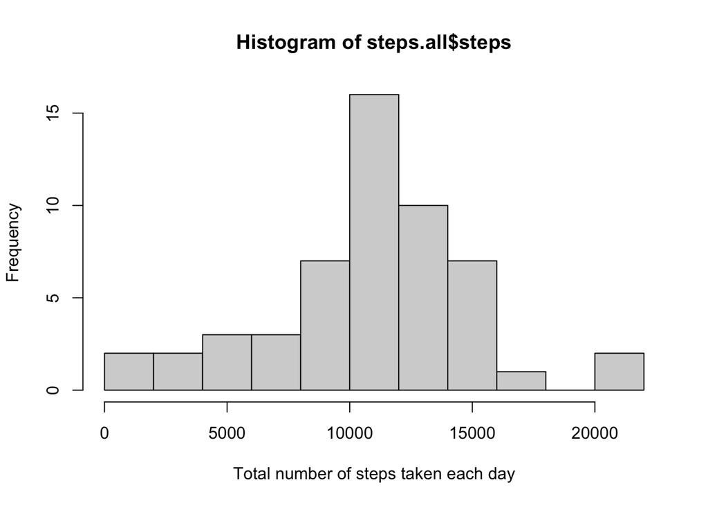

```r
hist(steps.all$steps, breaks = 10, xlab='Total number of steps taken each day')
```

#### Calculate and report the mean and median of the total number of steps taken per day

```r
mean(steps.all$steps, na.rm = TRUE)
```

```
## [1] 10766.19
```

```r
median(steps.all$steps, na.rm = TRUE)
```

```
## [1] 10765
```

- The mean of daily is1.0766189^{4} steps.
- The median of daily is 10765 steps.

### **What is the average daily activity pattern?**

#### Make a time series plot (i.e. type = “l”) of the 5-minute interval (x-axis) and the average number of steps taken, averaged across all days (y-axis)

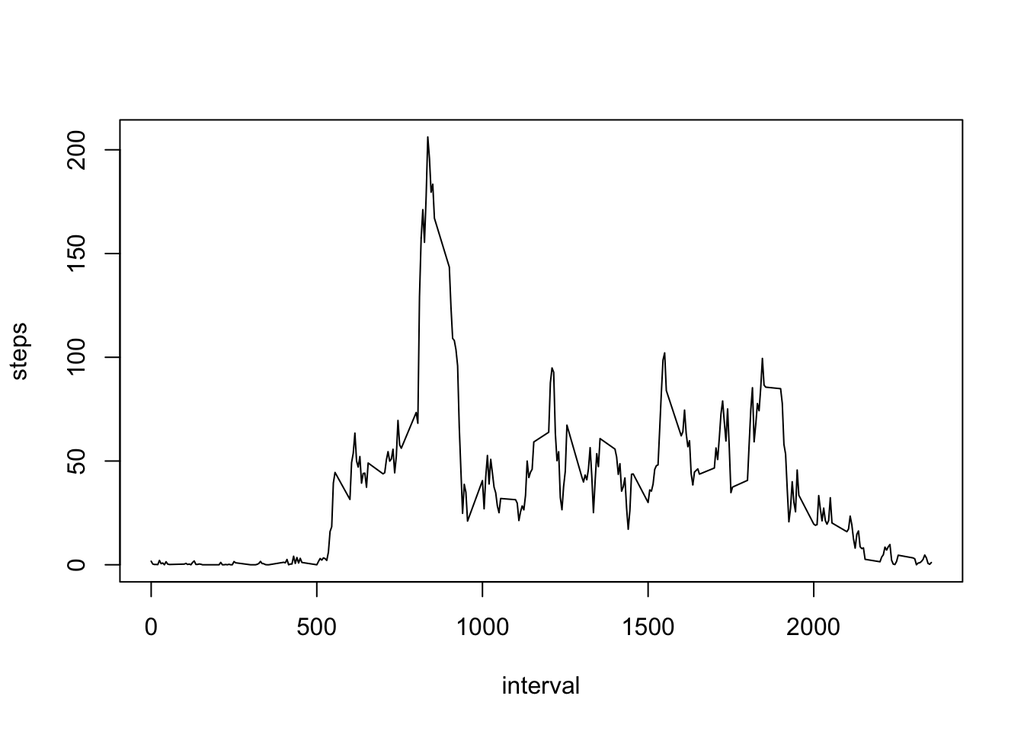

```r
steps.interval<-aggregate(steps~interval, data=activity, mean,na.rm=TRUE)
plot(steps~interval,data=steps.interval,type="l")
```

#### Which 5-minute interval, on average across all the days in the dataset, contains the maximum number of steps?

```r
MaxInt5min <- steps.interval[which.max(steps.interval$steps),]$interval
```

- On average across all the days in the dataset, the 5-min interval that contains the maximum number of steps is 835

### **Imputing Missing Values**

#### Calculate and report the total number of missing values in the dataset (i.e. the total number of rows with NAs)

```r
sum(is.na(activity$steps))
```

```
## [1] 2304
```

- The total missing number of rows: 2304

#### Devise a strategy for filling in all of the missing values in the dataset. The strategy does not need to be sophisticated. For example, you could use the mean/median for that day, or the mean for that 5-minute interval, etc.

```r
activity$imputedSteps <- ifelse(!is.na(activity$steps), activity$steps, round(steps.interval$steps[match(activity$interval, steps.interval$interval)],0))
```

#### Create a new dataset that is equal to the original dataset but with the missing data filled in.

```r
activeImputed <- activity[-c(1)]
activeImputed <- activeImputed[, c(3,1,2)]
names(activeImputed)[1] <- paste("steps")
```

#### Make a histogram of the total number of steps taken each day and Calculate and report the mean and median total number of steps taken per day.

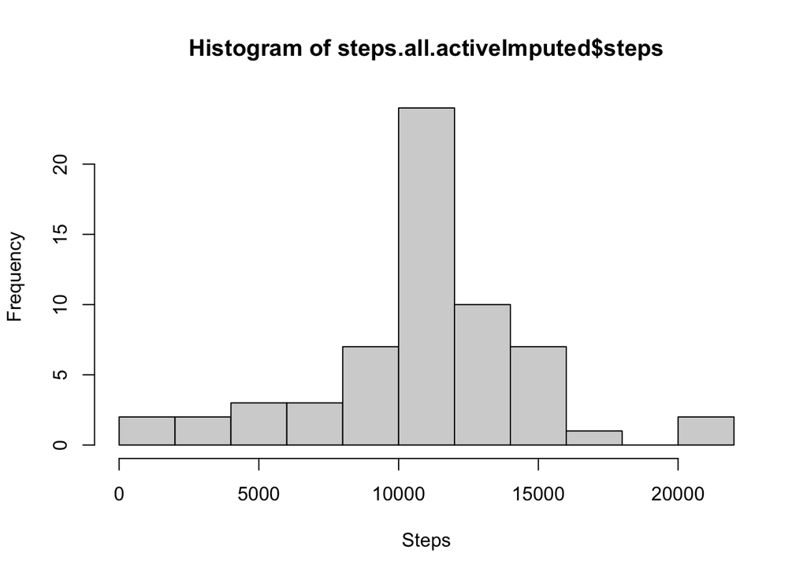

```r
steps.all.activeImputed <-aggregate(steps~date, activeImputed ,sum)
hist(steps.all.activeImputed$steps, breaks = 10, xlab='Steps' )
```

```r
mean(steps.all.activeImputed$steps)
```

```
## [1] 10765.64
```

```r
median(steps.all.activeImputed$steps)
```

```
## [1] 10762
```

- The NEW mean of daily steps is 1.0765639^{4} steps.
- the NEW median of daily steps is 1.0762^{4} steps.

### **Are there differences in activity patterns between weekdays and weekends?**

#### Create a new factor variable in the dataset with two levels – “weekday” and “weekend” indicating whether a given date is a weekday or weekend day.

```r
activeImputed$date <- as.Date(activeImputed$date, format="%Y-%m-%d")
activeImputed$weekday <- weekdays(activeImputed$date)
activeImputed$DayType <- ifelse(activeImputed$weekday=='Saturday' | activeImputed$weekday=='Sunday', 'weekend','weekday')
```

#### Make a panel plot containing a time series plot (i.e. type = “l”) of the 5-minute interval (x-axis) and the average number of steps taken, averaged across all weekday days or weekend days (y-axis).

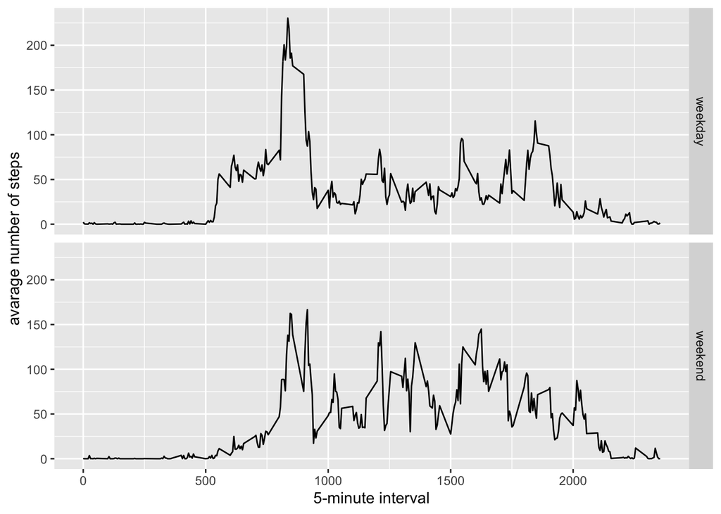

```r
library(ggplot2)
steps.int.Daytype.activeImputed <- aggregate(steps~interval+DayType, activeImputed ,mean)
ggplot(steps.int.Daytype.activeImputed, aes(interval, steps)) +
    geom_line() +
    facet_grid(DayType ~ .) +
    xlab("5-minute interval") +
    ylab("avarage number of steps")
```